# Lab 8 - Multiple Indicator, Multiple Causes - MIMIC Models

Adam Garber

Factor Analysis ED 216B - Instructor: Karen Nylund-Gibson

March 30, 2020

# 1 Lab 8 outline

1. Prepare, wrangle, and explore data
2. Run an unconditional CFA baseline model
3. Specify a MIMIC model with a single binary covariate
4. Specify a MIMIC model and probe for DIF
5. Specify a MIMIC model with a DIF parameter
6. Specify a MIMIC model with two binary covariates & an interaction
7. Specify a MIMIC model with three continuous covariates
8. Experiment with path diagram notation & formatting
9. $\color{red}{\text{We will keep close track of parameters and their status throughout lab}}$

## 1.1 Getting started - following the routine:

1. Create an R-Project
2. Load & istall packages (we will test a NEW method today)

## 1.2 R-Project instructions:

1. click “NEW PROJECT” (upper right corner of window)
2. choose option “NEW DIRECTORY”
3. choose location of project ($\color{red}{\text{too many nested folders = bad for `MplusObject` function}}$)

Within R-studio under the files pane (bottom right):

1. click “New Folder” and name folder “data”
2. click “New Folder” and name folder “mimic_mplus”
3. click “New Folder” and name folder “figures”

## 1.3 loading (and installing when needed) packages:

$\color{red}{\text{We are testing an alternative method for this procedure today (simply run the code below)}}$

```r
if (!require(pacman)) { install.packages("pacman"); library(pacman) }

p_load(knitr, tidyverse, here, semPlot, DiagrammeR, MplusAutomation,
       rhdf5, texreg, stargazer, gtsummary, gt, kableExtra)
```

DATA SOURCE: This lab exercise utilizes the NCES public-use dataset: Education Longitudinal Study of 2002 (Lauff & Ingels, 2014) [$\color{blue}{\text{See website: nces.ed.gov}}$](https://nces.ed.gov/surveys/els2002/avail_data.asp)

# 2 ~~~~~~~~~~~~~~~~ Lab 8 - Begin ~~~~~~~~~~~~~~~~

## 2.1 read in data

```r
lab_data <- read_csv(here("data", "els_sub5_data.csv"))
```

## 2.2 take a look at the EFA data (same indicators used for lab 4)

```r
stargazer(as.data.frame(lab_data), type="text", digits=1)
```

[output not shown]

## 2.3 alternative way to make summary tables using package {`gtsummary`}

```r
table_data <- lab_data %>%
  dplyr::select(byincome, mth_test, rd_test, freelnch, bystlang)

table2 <- tbl_summary(table_data,
                      by = bystlang,   # split table by group "bystlang" ()
                      missing = "no"   # don't list missing data separately
                      ) %>%
  add_n() %>%                          # add column with total number of non-missing observations
  add_p() %>%                          # test if there's difference between groups
  bold_labels()

table2
```

| **Characteristic** | **N** | **0**, N = 117<sup>1</sup> | **1**, N = 632<sup>1</sup> | **p-value**<sup>2</sup> |
| --- | --- | --- | --- | --- |
| byincome | 749 | 8.00 (6.00, 10.00) | 10.00 (8.00, 11.00) | <0.001 |
| mth_test | 749 | 48 (41, 55) | 52 (45, 58) | <0.001 |
| rd_test | 749 | 46 (40, 52) | 51 (44, 58) | <0.001 |
| freelnch | 685 |  |  | <0.001 |
| 1 |  | 23 (23%) | 222 (38%) |  |
| 2 |  | 9 (8.9%) | 67 (11%) |  |
| 3 |  | 14 (14%) | 82 (14%) |  |
| 4 |  | 9 (8.9%) | 72 (12%) |  |
| 5 |  | 15 (15%) | 89 (15%) |  |
| 6 |  | 18 (18%) | 30 (5.1%) |  |
| 7 |  | 13 (13%) | 22 (3.8%) |  |

<sup>*1*</sup> Statistics presented: median (IQR); n (%) <sup>*2*</sup> Statistical tests performed: Wilcoxon rank-sum test; chi-square test of independence

## 2.4 prepare dataframe for analysis (select & reorder columns)

```r
mimic_data <-  lab_data %>%
  select(bystlang, freelnch, byincome,                    # covariates
         stolen, t_hurt, p_fight, hit, damaged, bullied,  # factor 1 (indicators)
         safe, disrupt, gangs, rac_fght,                  # factor 2 (indicators)
         late, skipped, mth_read, mth_test, rd_test) %>%
  mutate(
    freelnch = case_when(    # Grade 10, percent free lunch - transform to binary
        freelnch <  5 ~ 0,   # < 50%
        freelnch >= 5 ~ 1))  # > 50%
```

# 3 Estimate the Unconditional Confirmatory Factor Analysis (CFA) model

## 3.1 $\color{red}{\text{Lab exercise: How many parameters are there in this model?}}$

**($\color{red}{\text{no cheating}}$ - i.e., jumping ahead)**

Number of parameters for the Unconditional CFA model:

- **??** item loadings
- **??** intercepts
- **??** residual variances
- **??** factor variances
- **??** factor co-variance

## 3.2 Make a simple CFA path diagram using package {`DiagrammeR`}

```r
# starting simple...

grViz(" digraph CFA_basic {

 node [shape=box]
 Y1; Y2; Y3; Y4; Y5;

 node [shape=circle, width = 0.9]
 F1;

 edge []
 F1->{Y1 Y2 Y3 Y4 Y5}

}")
```

[interactive chart not shown]

```r
cfa_m0  <- mplusObject(
  TITLE = "CFA model0 - LAB 8 mimic models",
  VARIABLE =
    "usevar = stolen-rac_fght;",

  ANALYSIS =
    "estimator = mlr;",

  MODEL =
    "FACTOR_1 by stolen t_hurt p_fight hit damaged bullied;

     FACTOR_2 BY safe disrupt gangs rac_fght;" ,

  PLOT = "type = plot3;",
  OUTPUT = "sampstat standardized residual modindices (3.84);",

  usevariables = colnames(mimic_data),
  rdata = mimic_data)

cfa_m0_fit <- mplusModeler(cfa_m0,
                            dataout=here("mimic_mplus", "lab8_mimic_data.dat"),
                            modelout=here("mimic_mplus", "lab8_cfa_model0.inp"),
                            check=TRUE, run = TRUE, hashfilename = FALSE)
```

```r
# Read in the model to R within the "mimic_mplus" folder
mimic_output1 <- readModels(here("Lab8_FA", "mimic_mplus", "lab8_cfa_model0.out"))
```

```
## Reading model:  /Users/agarber/github/project-site/Lab8_FA/mimic_mplus/lab8_cfa_model0.out
```

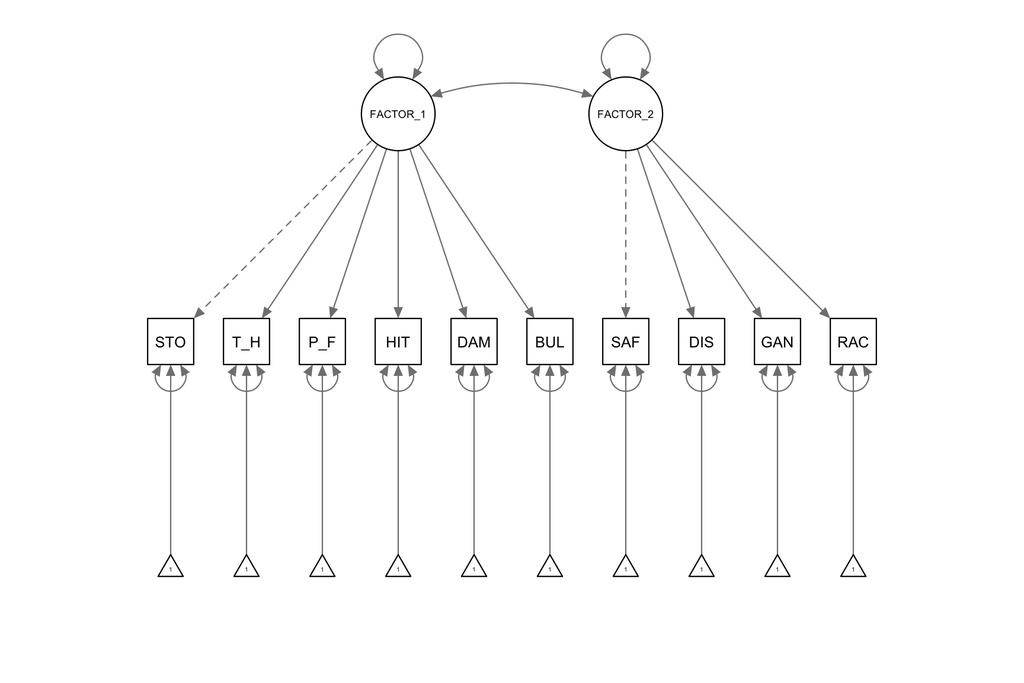

```r
# Plot model:
semPaths(mimic_output1,
         # intercepts=FALSE,
         # fixedStyle = c(1)
         )
```

```r
# ** comment out the arguments "intercepts" & "fixedStyle" to make all parameters explicit
```

## 3.3 $\color{red}{\text{Lab exercise: Count model parameters from the path diagram }}$

**(i.e., count number of arrows)**

# 4 MIMIC model 1 - single bivariate covariate

Number of parameters for the MIMIC model 1 = 33

- 8 item loadings (10 items - 2 fixed loadings)
- 10 intercepts
- 10 residual variances
- 2 factor variances
- 1 factor co-variance
- 1 covariate mean
- 1 covariate variance

```r
grViz(" digraph mimic_path_diagram {

graph [overlap = true, fontsize = 10,   # this is the 'graph' statement
       fontname = Times,
       label=
       'Figure 1: MIMIC model with single covariate.']

  node [shape = box]                   # this is the 'node' statement

  A; B; C; D; E;

  node [shape = box,
        label = 'Covariate']

  X;

  node [shape = circle, fixedsize = true,
        width = 0.9, label = 'Factor 1']

  F;

  edge [color = black]                   # this is the 'edge' statement

  F->{A B C D E}
  X->F

}")
```

[interactive chart not shown]

```r
mimic_m1  <- mplusObject(
  TITLE = "MIMIC model1 - LAB 8",
  VARIABLE =
    "usevar = freelnch stolen-rac_fght;",

  ANALYSIS =
    "estimator = mlr;",

  MODEL =
    "FACTOR_1 by stolen t_hurt p_fight hit damaged bullied;

     FACTOR_2 by safe disrupt gangs rac_fght;

     FACTOR_1 on freelnch;

     FACTOR_2 on freelnch;" ,

  PLOT = "type = plot3;",
  OUTPUT = "sampstat standardized residual modindices (3.84);",

  usevariables = colnames(mimic_data),
  rdata = mimic_data)

mimic_m1_fit <- mplusModeler(mimic_m1,
                            dataout=here("mimic_mplus", "lab8_mimic_data.dat"),
                            modelout=here("mimic_mplus", "lab8_mimic_model1.inp"),
                            check=TRUE, run = TRUE, hashfilename = FALSE)
```

# 5 MIMIC model 2 - probe for covariate -> indicator DIFF

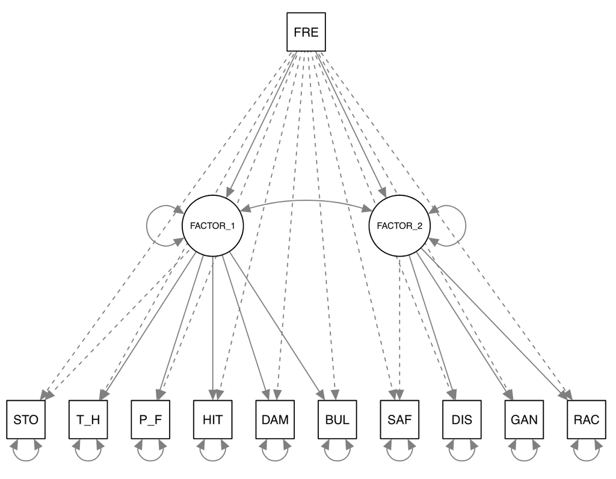

```r
mimic_m2  <- mplusObject(
  TITLE = "MIMIC model2 - LAB 8",
  VARIABLE =
    "usevar = freelnch stolen-rac_fght;",

  ANALYSIS =
    "estimator = mlr;",

  MODEL =
    "FACTOR_1 by stolen t_hurt p_fight hit damaged bullied;

     FACTOR_2 by safe disrupt gangs rac_fght;

     FACTOR_1 on freelnch;

     FACTOR_2 on freelnch;

     stolen-rac_fght on freelnch@0; ! to check DIFF see modification indices ",

  PLOT = "type = plot3;",
  OUTPUT = "sampstat standardized residual modindices (.1);",

  usevariables = colnames(mimic_data),
  rdata = mimic_data)

mimic_m2_fit <- mplusModeler(mimic_m2,
                            dataout=here("mimic_mplus", "lab8_mimic_data.dat"),
                            modelout=here("mimic_mplus", "lab8_mimic_model2.inp"),
                            check=TRUE, run = TRUE, hashfilename = FALSE)
```

```r
mimic_output2 <- readModels(here("mimic_mplus", "lab8_mimic_model2.out"))

# Plot model:
semPaths(mimic_output2,
          intercepts=FALSE,
          #fixedStyle = c(1)
         )
```

# 6 MIMIC model 3 - specify covariate -> indicator DIFF

Number of parameters for MIMIC model 3 = 34

- 8 indicator loadings (10 items - 2 fixed loadings)
- 10 intercepts
- 10 residual variances
- 2 factor variances
- 1 factor co-variance
- 1 covariate mean
- 1 covariate variance
- 1 DIF (covariate -> indicator)

```r
grViz(" digraph mimic_mode_3 {

graph [overlap = true, fontsize = 12, fontname = Times]

  node [shape = box]
  stolen; t_hurt; p_fight; hit; damaged; bullied; safe; disrupt; gangs; rac_fght;

  node [shape = box, label = 'Percent Free Lunch']
  X;

  node [shape = circle, fixedsize = true, width = 0.9, label = 'Factor 1']
  F1;

  node [shape = circle, fixedsize = true, width = 0.9, label = 'Factor 2']
  F2;

  edge [color = black]

  F1->{stolen t_hurt p_fight hit damaged bullied}
  F2->{safe disrupt gangs rac_fght}
  X->F1 X->F2 X->bullied
}")
```

[interactive chart not shown]

```r
mimic_m3  <- mplusObject(
  TITLE = "MIMIC model3 - LAB 8",
  VARIABLE =
    "usevar = freelnch stolen-rac_fght;",

  ANALYSIS =
    "estimator = mlr;",

  MODEL =
    "FACTOR_1 by stolen t_hurt p_fight hit damaged bullied;

     FACTOR_2 by safe disrupt gangs rac_fght;

     FACTOR_1 FACTOR_2 on freelnch;

     bullied on freelnch; ",

  PLOT = "type = plot3;",
  OUTPUT = "sampstat standardized residual modindices (3.84);",

  usevariables = colnames(mimic_data),
  rdata = mimic_data)

mimic_m1_fit <- mplusModeler(mimic_m3,
                            dataout=here("mimic_mplus", "lab8_mimic_data.dat"),
                            modelout=here("mimic_mplus", "lab8_mimic_model3.inp"),
                            check=TRUE, run = TRUE, hashfilename = FALSE)
```

# 7 MIMIC model 4 - two covariates & an interaction term

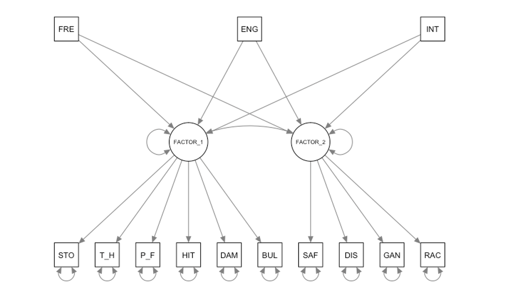

```r
mimic_m4  <- mplusObject(
  TITLE = "MIMIC model4 - LAB 8",
  VARIABLE =
    "usevar = freelnch stolen-rac_fght eng_2nd int;",

  ANALYSIS =
    "estimator = mlr;",

  DEFINE =
  "if bystlang == 1 THEN eng_2nd=0;
   if bystlang == 0 THEN eng_2nd=1;
  int = eng_2nd*freelnch;",

  MODEL =
    "FACTOR_1 by stolen t_hurt p_fight hit damaged bullied;

     FACTOR_2 by safe disrupt gangs rac_fght;

     FACTOR_1 FACTOR_2 on freelnch eng_2nd int; ",

  PLOT = "type = plot3;",
  OUTPUT = "sampstat standardized residual modindices (3.84);",

  usevariables = colnames(mimic_data),
  rdata = mimic_data)

mimic_m4_fit <- mplusModeler(mimic_m4,
                            dataout=here("mimic_mplus", "lab8_mimic_data.dat"),
                            modelout=here("mimic_mplus", "lab8_mimic_model4.inp"),
                            check=TRUE, run = TRUE, hashfilename = FALSE)
```

## 7.1 create a path diagram of MIMIC model 4

```r
# Read in the model to R within the "cfa_mplus" folder
mimic_output4 <- readModels(here("mimic_mplus", "lab8_mimic_model4.out"))

# Plot model:
semPaths(mimic_output4,
         intercepts=FALSE,
         fixedStyle = c(1))
```

# 8 MIMIC model 5 - three continuous covariates

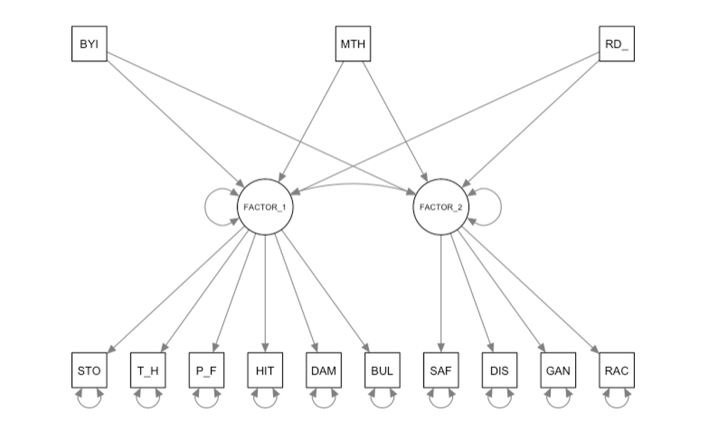

```r
mimic_m5  <- mplusObject(
  TITLE = "MIMIC model5 - LAB 8",
  VARIABLE =
    "usevar = byincome mth_test rd_test stolen-rac_fght;",

  ANALYSIS =
    "estimator = mlr;",

  MODEL =
    "FACTOR_1 by stolen t_hurt p_fight hit damaged bullied;

     FACTOR_2 by safe disrupt gangs rac_fght;

     FACTOR_1 FACTOR_2 on byincome mth_test rd_test; ",

  PLOT = "type = plot3;",
  OUTPUT = "sampstat standardized residual modindices (3.84);",

  usevariables = colnames(mimic_data),
  rdata = mimic_data)

mimic_m5_fit <- mplusModeler(mimic_m5,
                            dataout=here("mimic_mplus", "lab8_mimic_data.dat"),
                            modelout=here("mimic_mplus", "lab8_mimic_model5.inp"),
                            check=TRUE, run = TRUE, hashfilename = FALSE)
```

## 8.1 create a path diagram of MIMIC model 5

```r
# Read in the model to R
mimic_output5 <- readModels(here("mimic_mplus", "lab8_mimic_model5.out"))
```

```r
# Plot model:
semPaths(mimic_output5,
         intercepts=FALSE,
         fixedStyle = c(1)
         )

# ** Lab exercise: comment out the "intercepts" & "fixedStyle" arguments and then count model parameters
```

## 8.2 practice some formatting with `semPlot::semPaths()`

```r
semPaths(mimic_output5,
         "stdyx",  # plot the standardized parameter estimates (see output section: STDYX)
         intercepts=FALSE,
         fixedStyle = c(1),
         color= list(lat = c("light blue"," light green")),
         sizeMan = 10, sizeInt = 10, sizeLat = 10,
         edge.label.cex=.8,
         fade=FALSE
         )
```

[output not shown]

## 8.3 read all models and create table

```r
all_models <- readModels(here("mimic_mplus"))

table <- LatexSummaryTable(all_models,
                           keepCols=c(
                           "Filename", "Parameters","ChiSqM_Value",
                           "CFI", "TLI", "SRMR", "RMSEA_Estimate",
                           "RMSEA_90CI_LB", "RMSEA_90CI_UB"),
                      sortBy = "Filename")

table %>%
  kable(booktabs = T, linesep = "",
        col.names = c(
          "Model", "Par", "ChiSq",
          "CFI", "TLI", "SRMR", "RMSEA",
          "Lower CI", "Upper CI")) %>%
  kable_styling(c("striped"),
  full_width = F, position = "left")
```

[output not shown]

# 9 End of Lab 8

## 9.1 References

Hallquist, M. N., & Wiley, J. F. (2018). MplusAutomation: An R Package for Facilitating Large-Scale Latent Variable Analyses in Mplus. Structural equation modeling: a multidisciplinary journal, 25(4), 621-638.

Horst, A. (2020). Course & Workshop Materials. GitHub Repositories, https://https://allisonhorst.github.io/

Muthén, L.K. and Muthén, B.O. (1998-2017). Mplus User’s Guide. Eighth Edition. Los Angeles, CA: Muthén & Muthén

R Core Team (2017). R: A language and environment for statistical computing. R Foundation for Statistical Computing, Vienna, Austria. URL http://www.R-project.org/

Wickham et al., (2019). Welcome to the tidyverse. Journal of Open Source Software, 4(43), 1686, https://doi.org/10.21105/joss.01686